# Week7

Jessica Brown

2023-09-28

This is re-analyzing.. and etc stuff from Week 5 & maybe some stuff from Week 6. I am confused, so there may be lots of confusion here. Mostly, I want to revisit models I used in Week 5 to fully understand them more.

Also, I wanted to write the LSTM model in the Week 5 stuff, but it is just too long of a document and I need to break it up. I wrote the KNN models stuff in Week 5 document but wrote it during Week 7 which is right now. Likely, this will be a Week 7 & 8 document as I asked for an extension to work on this stuff from my professor.

He wants me to write general manuscript which I am doing on google docs, but I realized how much I don’t understand certain things and how I’m not confident in certain results and stuff.

I am mostly solid on SMS and ARIMA.. but I want to test what type of dataset that I am using. As every model has different parameters that can be used.. Just in general, I want to make sure I understand everything so I can write it down in my manuscript with references & just sensical things!!! SENSICAL!! I need to do such a thing because otherwise I am not satisfied or confident in what I did.

```r
library(lubridate)
library(here)
library(readr)
library(dplyr)
```

```r
library(ggplot2)

#First: Bring in all useful data that I have saved to text files for my convenience

data_2022 = read.table(here("Datasets", "data_2022.txt"))
fore_expxmth = read.table(here("Datasets", "fore_expxmth.txt"))
fore_holtexpxmth = read.table(here("Datasets", "fore_holtexpxmth.txt"))
fore_arimaauto = read.table(here("Datasets", "fore_arimaauto.txt"))
fore_arimamine = read.table(here("Datasets", "fore_arimamine.txt"))
prophet_sum = read.table(here("Datasets", "prophet_sum.txt"))
fore_knn = read.table(here("Datasets", "fore_knn.txt"))
date_list_2022 = read.table(here("Datasets", "date_list_2022.txt"))
data_MissingPerson_II = read.table(here("Datasets", "data_MissingPerson_II.txt"), fill = TRUE)
data_months_vertical = read.table(here("Datasets", "data_months_vertical.txt"))
error_tables = read.table(here("Datasets", "error_tables.txt"))

#We are using a specific LSTM model here that has since changed. With
#that being said, I decided to import its errors and change the error
#table manually
E1000_LRp0001 = read.table(here("Datasets", "LSTM_Errors_E1000_LRp0001.txt"))
error_tables$MAE[7] = E1000_LRp0001$MAE[1]
error_tables$TS[7] = E1000_LRp0001$TS[1]
error_tables$MSE[7] = E1000_LRp0001$MSE[1]
error_tables$RSFE[7] = E1000_LRp0001$RSFE[1]
```

Now to experiment with graphs

```r
#Turn all data into time-series for plotting ease
data_ts = ts(data_months_vertical, frequency = 12, start = c(2018, 1))
arimaauto_ts = ts(fore_arimaauto$Point.Forecast, frequency = 12, start = c(2022, 1))
expxmth_ts = ts(fore_expxmth$Point.Forecast, frequency = 12, start = c(2022, 1))
holtexpxmth_ts = ts(fore_holtexpxmth$Point.Forecast, frequency = 12, start = c(2022, 1))
knn_ts = ts(fore_knn$prediction.prediction, frequency = 12, start = c(2022, 1))
prophet_ts = ts(prophet_sum$Freq, frequency = 12, start = c(2022, 1))
actual_ts = ts(data_2022$Freq[49:54], frequency = 12, start = c(2022, 1))
arimamine_ts = ts(fore_arimamine$Point.Forecast, frequency = 12, start = c(2022, 1))

#Make a df for each of these time-series because time-series ain't cutting it

#Make list of null to make my life easier
list = data.frame(c(1:48))
i = 1
while(i <= 48){
  list[i] = list(NA)
  i = i + 1
}

#Do this for forecast dates (makes my life easier)
dates_2022 = c("2022-01", "2022-02", "2022-03", "2022-04", "2022-05", "2022-06")

arimaauto_df = data.frame(c(1:54))
arimaauto_df$x2 = 0
arimaauto_df$x2[1:48] = list$c.1.48.
arimaauto_df$x2[49:54] = arimaauto_ts
colnames(arimaauto_df) = c("y", "x")


expxmth_df = data.frame(c(1:54))
expxmth_df$x2 = 0
expxmth_df$x2[1:48] = list$c.1.48.
expxmth_df$x2[49:54] = expxmth_ts
colnames(expxmth_df) = c("y", "x")

holtexpxmth_df = data.frame(c(1:54))
holtexpxmth_df$x2 = 0
holtexpxmth_df$x2[1:48] = list$c.1.48.
holtexpxmth_df$x2[49:54] = holtexpxmth_ts
colnames(holtexpxmth_df) = c("y", "x")

knn_df = data.frame(c(1:54))
knn_df$x2 = 0
knn_df$x2[1:48] = list$c.1.48.
knn_df$x2[49:54] = knn_ts
colnames(knn_df) = c("y", "x")

prophet_df = data.frame(c(1:54))
prophet_df$x2 = 0
prophet_df$x2[1:48] = list$c.1.48.
prophet_df$x2[49:54] = prophet_ts
colnames(prophet_df) = c("y", "x")

arimamine_df = data.frame(c(1:54))
arimamine_df$x2 = 0
arimamine_df$x2[1:48] = list$c.1.48.
arimamine_df$x2[49:54] = arimamine_ts
colnames(arimamine_df) = c("y", "x")

actual_df = data.frame(c(1:54))
actual_df$x2 = 0
actual_df$x2[49:54] = actual_ts
actual_df$x2[1:48] = list$c.1.48.
colnames(actual_df) = c("y", "x")

data_df = data.frame(data_2022 %>%  filter(!row_number() %in% c(55:60)))
data_df$x2 = c(1:54)
colnames(data_df) = c ("y", "x")
data_df$y[49:54] = list
legend_df = knn_df

typeof(arimaauto_df$x)
```

```
## [1] "double"
```

```r
typeof(arimaauto_df$y)
```

```
## [1] "integer"
```

```r
#Now to plot the data
#plot(data_df$x, ylab = "Incident Reported Per Month", xlab = "Time", y = data_df$y) + lines(data_df$x, data_df$y) + lines(knn_df$x, type = "b", col = 4) + lines(holtexpxmth_df$x, type = "b", col = 3) + lines(prophet_df$x, type = "b", col = 2) + lines(arimaauto_df$x, type = "b", col = 1) + lines(expxmth_df$x, type = "b", col = 6) + lines(arimamine_df$x, type = "b", col = 5) + lines(expxmth_df$x, type = "p", col = 9)

#plot(data_df$x, ylab = "Incident Reported Per Month", xlab = "Time", y = data_df$y) + legend(35, 215, legend = c("knn", "holts", "proph", "a(011)", "a(532)", "sms"), col = c("#444", "#333", "#222", "#111", "#666", "#999"))

#lines(actual_df, type = "l", col = 1) + lines(arimaauto_df, type = "l", col = 2) + lines(expxmth_df, col = 3, type = "l") + lines(holtexpxmth_df, col = 4, type = "l")
knn_ts
```

```
##           Jan      Feb      Mar      Apr      May      Jun
## 2022 130.9028 134.5613 133.0665 118.9470 134.7342 131.4899
```

Here is the bar plot of Errors

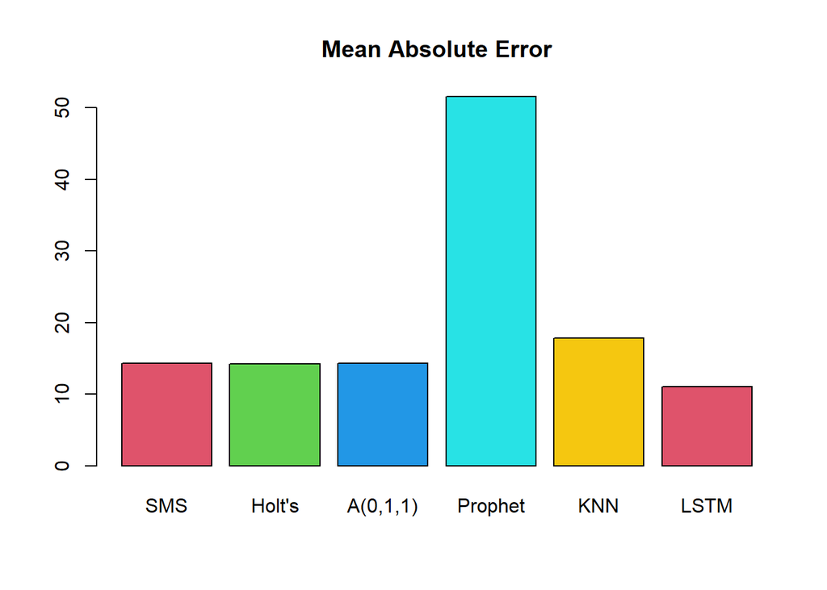

```r
#I don't want Arima(0,3,5) anymore, so it has been ex-commuicated from this graph
error_tables = error_tables[-c(3),]
error_tables = subset(error_tables, )
barplot(error_tables$MAE, names.arg = c("SMS", "Holt's", "A(0,1,1)", "Prophet", "KNN", "LSTM"), col = c(2,3,4,5,7), main = "Mean Absolute Error")
```

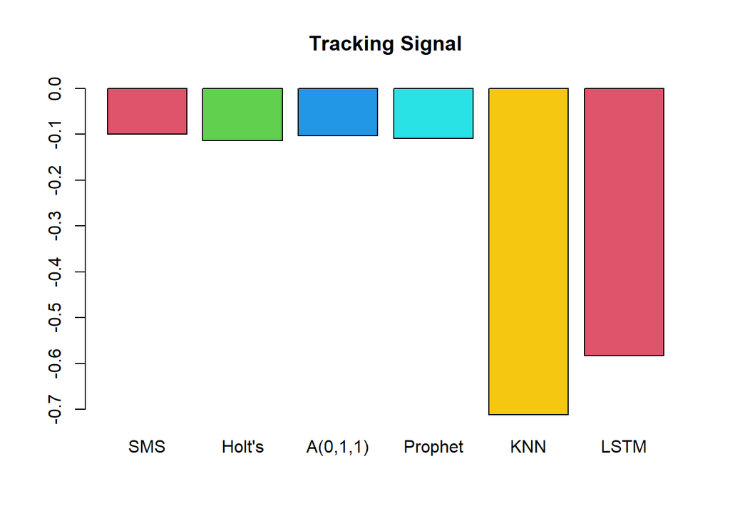

```r
barplot(error_tables$TS, names.arg = c("SMS", "Holt's", "A(0,1,1)", "Prophet", "KNN", "LSTM"), col = c(2,3,4,5,7), main = "Tracking Signal")
```

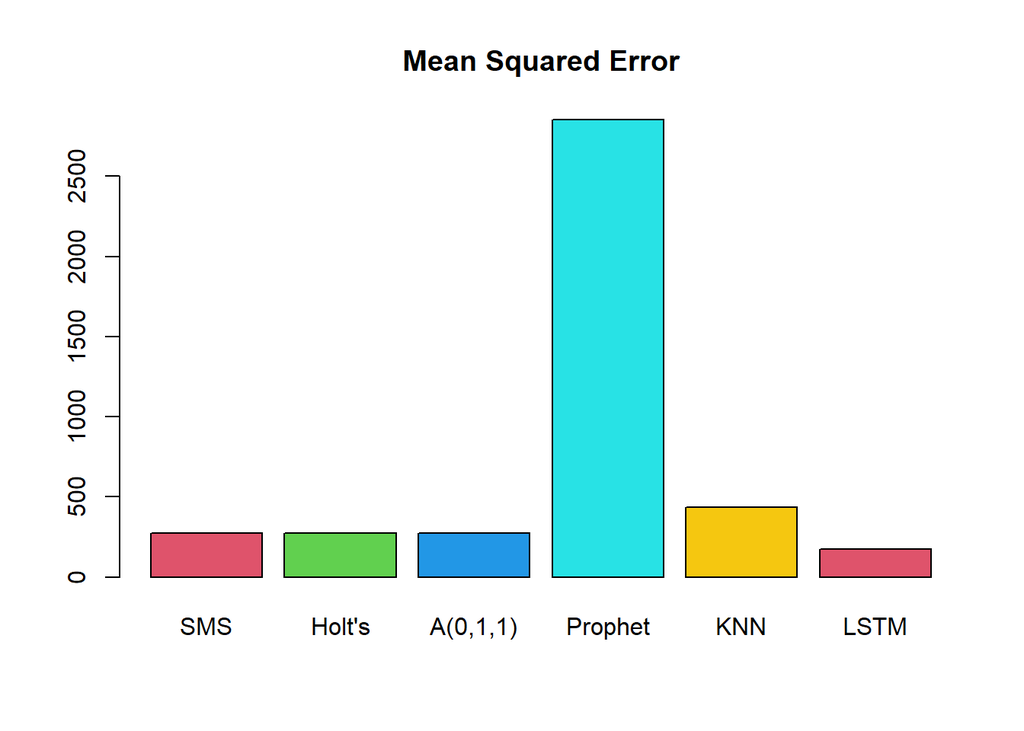

```r
barplot(error_tables$MSE, names.arg = c("SMS", "Holt's", "A(0,1,1)", "Prophet", "KNN", "LSTM"), col = c(2,3,4,5,7), main = "Mean Squared Error")
```

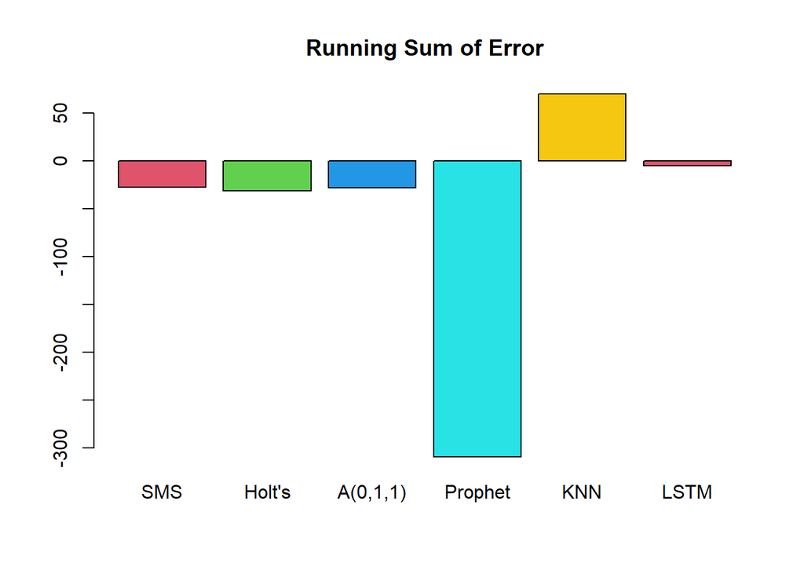

```r
barplot(error_tables$RSFE, names.arg = c("SMS", "Holt's", "A(0,1,1)", "Prophet", "KNN", "LSTM"), col = c(2,3,4,5,7), main = "Running Sum of Error")
```